# QMM_Assignment_5

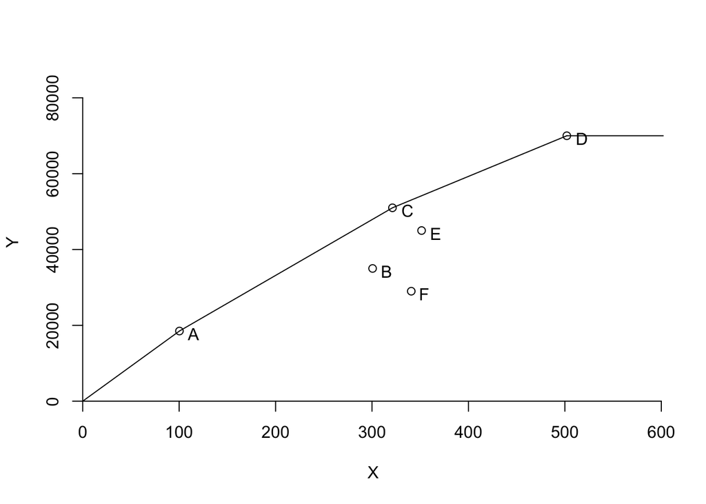

```r
dea.plot(x,y,RTS="drs",txt = rownames(x))
```

1d.**dea(x, y, RTS = “vrs”):** This line performs DEA analysis using the dea function. It takes x (input matrix), y (output matrix), and an additional parameter VRS set to “vrs,” which specifies the Variable Returns to Scale (VRS) assumption. VRS assumes that we may experience increasing returns to scale (IRS), while others may experience decreasing returns to scale (DRS), or they might operate at constant returns to scale (CRS). **When we use dea(x, y, RTS=“vrs”), the VRS assumption is applied, it means scale of production can vary and so does the efficiency**

```r
VRS <- dea(x,y,RTS="vrs")
VRS
```

[output not shown]

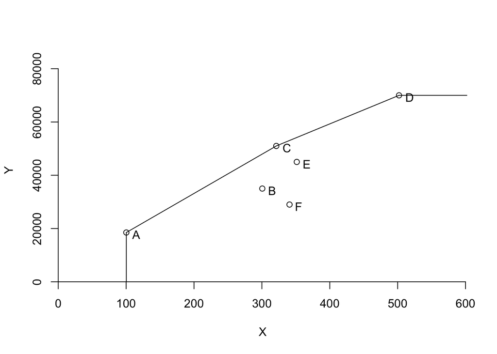

```r
dea.plot(x,y,RTS="vrs",txt = rownames(x))
```

1e. **dea(x, y, RTS = “fdh”):** This line performs DEA analysis using the dea function. It takes x (input matrix), y (output matrix), and an additional parameter FDH set to “fdh,” which specifies the Free Disposable Hull (FDH) assumption. FDH assumes that we may experience constant returns to scale (CRS) or variable returns to scale (VRS). **When we use dea(x, y, RTS=“fdh”), the FDH assumption is applied, it is assume while taking into account that we can freely dispose of unused inputs or produce more output without incurring extra costs**

```r
FDH <- dea(x,y,RTS="fdh")
FDH
```

```
[1] 1.0000 1.0000 1.0000 1.0000 1.0000 0.8824
```

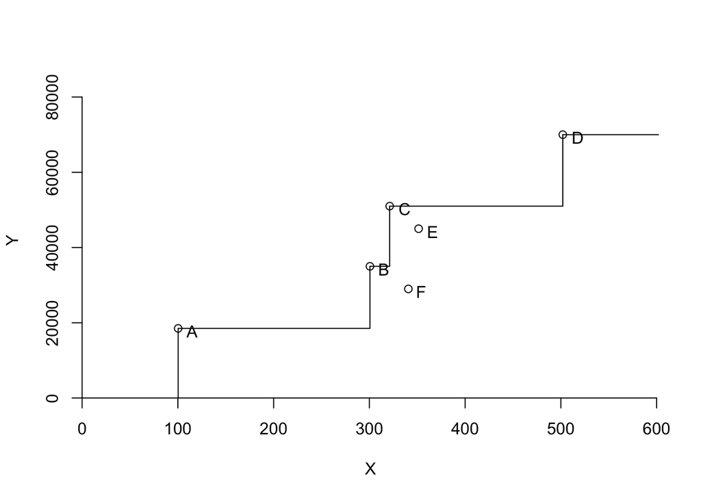

```r
dea.plot(x,y,RTS="fdh",txt = rownames(x))
```

1.f **dea(x, y, RTS = “frh”):** This line performs DEA analysis using the dea function. It takes x (input matrix), y (output matrix), and an additional parameter FRH set to “frh,” which specifies the Free Redistribution of non-discretionary Inputs and Outputs (FRH) assumption. **When we use dea(x, y, RTS=“frh”), the FDH assumption is applied, it assumes that non-discretionary inputs and outputs can be fully redistributed among DMUs without cost. This means that if a DMU is inefficient in its utilization of non-discretionary inputs or generation of non-discretionary outputs, these resources or outputs can be fully redistributed to other DMUs without incurring any additional cost.**

```r
FRH <- dea(x,y,RTS="add")
FRH
```

```
     A      B      C      D      E      F
1.0000 1.0000 1.0000 1.0000 1.0000 0.8824
```

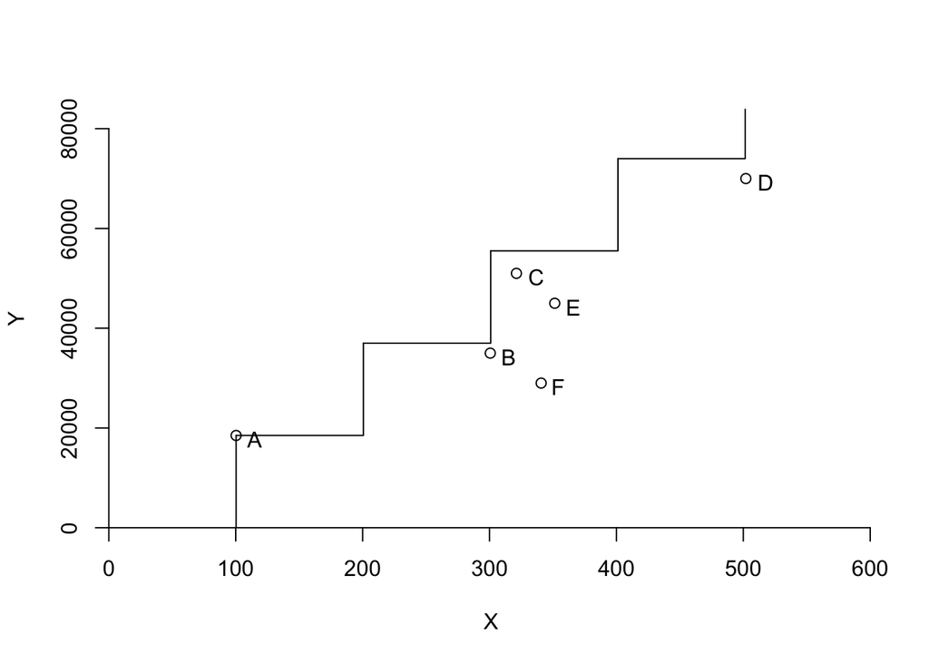

```r
dea.plot(x,y,RTS="add",txt = rownames(x))
```

**2.Determine the Peers and Lambdas under each of the above assumptions.**

**Peer groups are sets of other DMUs that are considered efficient when evaluating a specific DMU. In other words, it shows which DMUs are considered benchmarks for each DMU.**

```r
# This line calculates and displays the peer groups and lambda for each CRS DMU.
peers(CRS)
```

```
  peer1 peer2
A     1    NA
B     2    NA
C     1     4
D     4    NA
E     1     4
F     1     2
```

```r
round(lambda(CRS),2)
```

```
   L_A  L_B  L_D
A 1.00 0.00 0.00
B 0.00 1.00 0.00
C 2.58 0.00 0.05
D 0.00 0.00 1.00
E 0.26 0.00 0.57
F 0.22 0.71 0.00
```

```r
# This line calculates and displays the peer groups and lambda for each IRS DMU.
peers(IRS)
```

```
  peer1 peer2
A     1    NA
B     2    NA
C     1     4
D     4    NA
E     1     4
F     1     2
```

```r
round(lambda(IRS),2)
```

```
   L_A L_B  L_D
A 1.00 0.0 0.00
B 0.00 1.0 0.00
C 2.58 0.0 0.05
D 0.00 0.0 1.00
E 0.44 0.0 0.56
F 0.30 0.7 0.00
```

```r
# This line calculates and displays the peer groups and lambda for each DRS DMU.
peers(DRS)
```

```
  peer1 peer2
A     1    NA
B     2    NA
C     3    NA
D     4    NA
E     1     4
F     1     2
```

```r
round(lambda(DRS),2)
```

```
   L_A  L_B L_C  L_D
A 1.00 0.00   0 0.00
B 0.00 1.00   0 0.00
C 0.00 0.00   1 0.00
D 0.00 0.00   0 1.00
E 0.26 0.00   0 0.57
F 0.22 0.71   0 0.00
```

```r
# This line calculates and displays the peer groups and lambda for each VRS DMU.
peers(VRS)
```

```
  peer1 peer2
A     1    NA
B     2    NA
C     3    NA
D     4    NA
E     1     4
F     1     2
```

```r
round(lambda(VRS),2)
```

```
   L_A L_B L_C  L_D
A 1.00 0.0   0 0.00
B 0.00 1.0   0 0.00
C 0.00 0.0   1 0.00
D 0.00 0.0   0 1.00
E 0.44 0.0   0 0.56
F 0.30 0.7   0 0.00
```

```r
# This line calculates and displays the peer groups and lambda for each FRH DMU.
peers(FRH)
```

```
  peer1
A     1
B     2
C     3
D     4
E     5
F     2
```

```r
round(lambda(FRH),2)
```

```
  L_A L_B L_C L_D L_E
A   1   0   0   0   0
B   0   1   0   0   0
C   0   0   1   0   0
D   0   0   0   1   0
E   0   0   0   0   1
F   0   1   0   0   0
```

```r
# This line calculates and displays the peer groups and lambda for each FDH DMU.
peers(FDH)
```

```
  peer1
A     1
B     2
C     3
D     4
E     5
F     2
```

```r
round(lambda(FDH),2)
```

```
  L_A L_B L_C L_D L_E
A   1   0   0   0   0
B   0   1   0   0   0
C   0   0   1   0   0
D   0   0   0   1   0
E   0   0   0   0   1
F   0   1   0   0   0
```

**3.Summarize your results in a tabular format.**

- Results for CRS:

```r
crs.df=cbind(peers(CRS),round(lambda(CRS),2))
crs.df=data.frame(crs.df)
crs.df %>%
  kable(align = "c") %>%
  kable_classic() %>%
  add_header_above(c("Facility"=1,"Peers"=2,"Lambda Values"=3))
```

| Facility | Peers peer1 | Peers peer2 | Lambda Values L_A | Lambda Values L_B | Lambda Values L_D |
| --- | --- | --- | --- | --- | --- |
| A | 1 | NA | 1.00 | 0.00 | 0.00 |
| B | 2 | NA | 0.00 | 1.00 | 0.00 |
| C | 1 | 4 | 2.58 | 0.00 | 0.05 |
| D | 4 | NA | 0.00 | 0.00 | 1.00 |
| E | 1 | 4 | 0.26 | 0.00 | 0.57 |
| F | 1 | 2 | 0.22 | 0.71 | 0.00 |

- Results for IRS:

```r
irs.df=cbind(peers(IRS),round(lambda(IRS),2))
irs.df=data.frame(irs.df)
irs.df %>%
  kable(align = "c") %>%
  kable_classic() %>%
  add_header_above(c("Facility"=1,"Peers"=2,"Lambda Values"=3))
```

| Facility | Peers peer1 | Peers peer2 | Lambda Values L_A | Lambda Values L_B | Lambda Values L_D |
| --- | --- | --- | --- | --- | --- |
| A | 1 | NA | 1.00 | 0.0 | 0.00 |
| B | 2 | NA | 0.00 | 1.0 | 0.00 |
| C | 1 | 4 | 2.58 | 0.0 | 0.05 |
| D | 4 | NA | 0.00 | 0.0 | 1.00 |
| E | 1 | 4 | 0.44 | 0.0 | 0.56 |
| F | 1 | 2 | 0.30 | 0.7 | 0.00 |

- Results for DRS:

```r
drs.df=cbind(peers(DRS),round(lambda(DRS),2))
drs.df=data.frame(drs.df)
drs.df %>%
  kable(align = "c") %>%
  kable_classic() %>%
  add_header_above(c("Facility"=1,"Peers"=2,"Lambda Values"=4))
```

| Facility | Peers peer1 | Peers peer2 | Lambda Values L_A | Lambda Values L_B | Lambda Values L_C | Lambda Values L_D |
| --- | --- | --- | --- | --- | --- | --- |
| A | 1 | NA | 1.00 | 0.00 | 0 | 0.00 |
| B | 2 | NA | 0.00 | 1.00 | 0 | 0.00 |
| C | 3 | NA | 0.00 | 0.00 | 1 | 0.00 |
| D | 4 | NA | 0.00 | 0.00 | 0 | 1.00 |
| E | 1 | 4 | 0.26 | 0.00 | 0 | 0.57 |
| F | 1 | 2 | 0.22 | 0.71 | 0 | 0.00 |

- Results for VRS:

```r
vrs.df=cbind(peers(VRS),round(lambda(VRS),2))
vrs.df=data.frame(vrs.df)
vrs.df %>%
  kable(align = "c") %>%
  kable_classic() %>%
  add_header_above(c("Facility"=1,"Peers"=2,"Lambda Values"=4))
```

| Facility | Peers peer1 | Peers peer2 | Lambda Values L_A | Lambda Values L_B | Lambda Values L_C | Lambda Values L_D |
| --- | --- | --- | --- | --- | --- | --- |
| A | 1 | NA | 1.00 | 0.0 | 0 | 0.00 |
| B | 2 | NA | 0.00 | 1.0 | 0 | 0.00 |
| C | 3 | NA | 0.00 | 0.0 | 1 | 0.00 |
| D | 4 | NA | 0.00 | 0.0 | 0 | 1.00 |
| E | 1 | 4 | 0.44 | 0.0 | 0 | 0.56 |
| F | 1 | 2 | 0.30 | 0.7 | 0 | 0.00 |

- Results for FDH:

```r
fdh.df=cbind(peers(FDH),round(lambda(FDH),2))
fdh.df=data.frame(fdh.df)
fdh.df %>%
  kable(align = "c") %>%
  kable_classic() %>%
  add_header_above(c("Facility"=1,"Peers"=1,"Lambda Values"=5))
```

| Facility | Peers peer1 | Lambda Values L_A | Lambda Values L_B | Lambda Values L_C | Lambda Values L_D | Lambda Values L_E |
| --- | --- | --- | --- | --- | --- | --- |
| A | 1 | 1 | 0 | 0 | 0 | 0 |
| B | 2 | 0 | 1 | 0 | 0 | 0 |
| C | 3 | 0 | 0 | 1 | 0 | 0 |
| D | 4 | 0 | 0 | 0 | 1 | 0 |
| E | 5 | 0 | 0 | 0 | 0 | 1 |
| F | 2 | 0 | 1 | 0 | 0 | 0 |

- Results for FRH:

```r
frh.df=cbind(peers(FRH),round(lambda(FRH),2))
frh.df=data.frame(frh.df)
frh.df %>%
  kable(align = "c") %>%
  kable_classic() %>%
  add_header_above(c("Facility"=1,"Peers"=1,"Lambda Values"=5))
```

| Facility | Peers peer1 | Lambda Values L_A | Lambda Values L_B | Lambda Values L_C | Lambda Values L_D | Lambda Values L_E |
| --- | --- | --- | --- | --- | --- | --- |
| A | 1 | 1 | 0 | 0 | 0 | 0 |
| B | 2 | 0 | 1 | 0 | 0 | 0 |
| C | 3 | 0 | 0 | 1 | 0 | 0 |
| D | 4 | 0 | 0 | 0 | 1 | 0 |
| E | 5 | 0 | 0 | 0 | 0 | 1 |
| F | 2 | 0 | 1 | 0 | 0 | 0 |